# Blog2

Yasith

3 June 2018

### Plot 1

[figure not shown]

```r
min <- min %>%
        filter(min$MP.â.. > 300)

ggplot(min, aes(x= MP.â.. , y= USG., colour="Tm", label=Player))+
  geom_point() +
geom_text(aes(label=ifelse(MP.â..> 700 ,as.character(Player),'')),hjust=0.9,vjust=-0.5) +
  ggtitle("Is this guy human?", subtitle = "Usage Rate vs. Minutes per game, for players with at least 300 minutes in the 2018 playoffs") + scale_color_fivethirtyeight("cyl") +
  theme_fivethirtyeight()
```

### Table of Percent per rd by player

##### percent points = points scored by player/ totoal points by both teams per round

##### sum(points by player) group by round

##### sum(points by rd)

```r
percent <- read.csv('PLAYOFFSDB.csv', header = TRUE )
 head(percent)
```

```
##   ï..Rk            Player TEAM RD Age G GS  MP FG FGA X3P X3PA FT FTA ORB
## 1     1 Jonas Valanciunas   TR RW  25 6  6 148 33  57   2    3 13  15  14
## 2     2       Serge Ibaka   TR RW  28 6  6 172 19  44   6   14  9  13   7
## 3     3        Kyle Lowry   TR RW  31 6  6 217 36  76  17   39 14  18   2
## 4     4      Jakob Poeltl   TR RW  22 6  0  96 14  22   0    1  9  13  12
## 5     5     Pascal Siakam   TR RW  23 6  0  96 14  25   2    3  8  12   6
## 6     6     DeMar DeRozan   TR RW  28 6  6 218 58 133  10   26 34  42   3
##   DRB TRB AST STL BLK TOV PF PTS   FG.  X3P.   FT. MP.1 PTS.1 TRB.1 AST.1
## 1  42  56   6   4   8  10 12  81 0.579 0.667 0.867 24.6  13.5   9.3   1.0
## 2  35  42   7   1   8   9 12  53 0.432 0.429 0.692 28.7   8.8   7.0   1.2
## 3  27  29  50  12   0  18 22 103 0.474 0.436 0.778 36.1  17.2   4.8   8.3
## 4  14  26   5   2   3   7 20  37 0.636 0.000 0.692 16.1   6.2   4.3   0.8
## 5  18  24   5   1   6   3 13  38 0.560 0.667 0.667 16.0   6.3   4.0   0.8
## 6  17  20  29   2   1  15  9 160 0.436 0.385 0.810 36.4  26.7   3.3   4.8
##   STL.1 BLK.1
## 1   0.7   1.3
## 2   0.2   1.3
## 3   2.0   0.0
## 4   0.3   0.5
## 5   0.2   1.0
## 6   0.3   0.2
```

# player_scorepercent(x,r) = player_score(x,r)/ sum(team_score(r))

# Points

```
## # A tibble: 356 x 5
##    Round TotalPoints Player            PlayerPoints percentage
##    <fct>       <int> <fct>                    <int>      <dbl>
##  1 CI           1368 LeBron James               241      0.176
##  2 CB           1360 LeBron James               235      0.173
##  3 CT            892 LeBron James               136      0.152
##  4 NP            880 Anthony Davis              132      0.150
##  5 GR           1441 Kevin Durant               213      0.148
##  6 UO           1240 Russell Westbrook          176      0.142
##  7 GR           1441 James Harden               201      0.139
##  8 GS           1012 Kevin Durant               141      0.139
##  9 UO           1240 Donovan Mitchell           171      0.138
## 10 HM           1060 James Harden               145      0.137
## # ... with 346 more rows
```

# Assists

```r
sumassits <- percent%>%
  group_by(RD) %>%
  summarise(sum(AST))

playerassits <- percent %>%
  group_by(Player, RD)%>%
  summarise(sum(AST))

assistspercent <-full_join(sumassits, playerassits, by= "RD")
colnames(assistspercent) <- c("Round", "Totalassits", "Player", "Playerassits")

for(i in 1:nrow(assistspercent)){
  assistspercent$percentage[i] <- assistspercent$Playerassits[i] / assistspercent$Totalassits[i]
}
assistspercent %>%
  arrange(desc(percentage))
```

```
## # A tibble: 356 x 5
##    Round Totalassits Player            Playerassits percentage
##    <fct>       <int> <fct>                    <int>      <dbl>
##  1 NP            182 Rajon Rondo                 53      0.291
##  2 RW            273 John Wall                   69      0.253
##  3 CT            182 LeBron James                45      0.247
##  4 CB            271 LeBron James                59      0.218
##  5 UO            218 Russell Westbrook           45      0.206
##  6 CI            268 LeBron James                54      0.201
##  7 GP            290 Rajon Rondo                 57      0.197
##  8 UO            218 Ricky Rubio                 42      0.193
##  9 CT            182 Kyle Lowry                  35      0.192
## 10 RW            273 Kyle Lowry                  50      0.183
## # ... with 346 more rows
```

# Rebounds

```r
sumrebs <- percent%>%
  group_by(RD) %>%
  summarise(sum(TRB))

playerreb <- percent %>%
  group_by(Player, RD)%>%
  summarise(sum(TRB))

rebpercent <-full_join(sumrebs, playerreb, by= "RD")
colnames(rebpercent) <- c("Round", "Totalreb", "Player", "Playerreb")

for(i in 1:nrow(rebpercent)){
  rebpercent$percentage[i] <- rebpercent$Playerreb[i] / rebpercent$Totalreb[i]
}
rebpercent %>%
  arrange(desc(percentage))
```

```
## # A tibble: 356 x 5
##    Round Totalreb Player             Playerreb percentage
##    <fct>    <int> <fct>                  <int>      <dbl>
##  1 HM         442 Clint Capela              71      0.161
##  2 CT         310 Jonas Valanciunas         49      0.158
##  3 BP         452 Joel Embiid               70      0.155
##  4 GP         484 Anthony Davis             74      0.153
##  5 HM         442 Karl-Anthony Towns        67      0.152
##  6 CT         310 Kevin Love                46      0.148
##  7 GR         594 Draymond Green            83      0.140
##  8 NP         347 Anthony Davis             47      0.135
##  9 UO         545 Russell Westbrook         72      0.132
## 10 GS         425 Draymond Green            56      0.132
## # ... with 346 more rows
```

```r
df <-merge( Scorepercent,
  merge(assistspercent, rebpercent, by.x = (c("Round", "Player")), by.y = c("Round", "Player")),
  by.x = c("Round", "Player"), by.y = c("Round", "Player")
)

# df1 <-
  df1 <- data.frame(df %>%
        select("Round", "Player", "percentage", "percentage.x", "percentage.y")  %>% #x =assits, #y = rebounds
          rowwise() %>%
          mutate(average = mean(c(percentage, percentage.x, percentage.y))) %>%
          ungroup() %>%
          arrange(desc(average)))

  # x <- function(div){

  # }
  colnames(df1) <- c("Round", "Player", "PPTS", "PASST", "PREBS", "ALL")

head(df1)
```

```
##   Round            Player       PPTS     PASST      PREBS       ALL
## 1    CT      LeBron James 0.15246637 0.2472527 0.10645161 0.1687236
## 2    CI      LeBron James 0.17616959 0.2014925 0.12704174 0.1682346
## 3    CB      LeBron James 0.17279412 0.2177122 0.10787671 0.1661277
## 4    UO Russell Westbrook 0.14193548 0.2064220 0.13211009 0.1601559
## 5    RW         John Wall 0.12018490 0.2527473 0.07039337 0.1477752
## 6    NP       Rajon Rondo 0.05113636 0.2912088 0.08645533 0.1429335
```

# Graphic 3

```r
jointab <- left_join(df1, percent, by = c("Round"="RD", "Player"="Player")) %>%
  select(Round, TEAM, Player, PPTS, PASST, PREBS, ALL)
# jointab %>% group_by(Round) %>% arrange(Round, desc(ALL) ) %>% filter(Round == "CB")
```

```r
x <- jointab %>%
  group_by( Round) %>%
  top_n(n = 4, wt = ALL) %>%
  arrange(Round, desc(ALL))

listx <- select(jointab, c("Round", "TEAM", "Player"))

head(x)
```

```
## # A tibble: 6 x 7
## # Groups:   Round [2]
##   Round TEAM  Player                  PPTS  PASST  PREBS    ALL
##   <fct> <fct> <fct>                  <dbl>  <dbl>  <dbl>  <dbl>
## 1 BM    MB    Giannis Antetokounmpo 0.126  0.144  0.117  0.129
## 2 BM    BC    Terry Rozier          0.0860 0.154  0.0524 0.0975
## 3 BM    BC    Al Horford            0.0888 0.0754 0.107  0.0903
## 4 BM    MB    Khris Middleton       0.121  0.0721 0.0629 0.0853
## 5 BP    PS    Joel Embiid           0.110  0.0789 0.155  0.114
## 6 BP    PS    Ben Simmons           0.0686 0.140  0.0907 0.0999
```

```r
library(data.table)
x <- data.table(x)
setkey(x, "TEAM")


# x %>% group_by(Round) %>%
  x[!duplicated(x)]
```

```
##     Round TEAM                Player       PPTS      PASST      PREBS
##  1:    BM   BC          Terry Rozier 0.08601399 0.15409836 0.05244755
##  2:    BM   BC            Al Horford 0.08881119 0.07540984 0.10664336
##  3:    BP   BC          Terry Rozier 0.09056244 0.09649123 0.07964602
##  4:    CB   BC          Terry Rozier 0.06985294 0.14760148 0.05821918
##  5:    CB   BC          Marcus Smart 0.04558824 0.16605166 0.04109589
##  6:    CB   BC            Al Horford 0.06985294 0.08487085 0.09075342
##  7:    CB   CC          LeBron James 0.17279412 0.21771218 0.10787671
##  8:    CI   CC          LeBron James 0.17616959 0.20149254 0.12704174
##  9:    CI   CC            Kevin Love 0.05847953 0.02611940 0.11796733
## 10:    CT   CC          LeBron James 0.15246637 0.24725275 0.10645161
## 11:    CT   CC            Kevin Love 0.09192825 0.03296703 0.14838710
## 12:    GP   GW        Draymond Green 0.06684734 0.17241379 0.12190083
## 13:    GP   GW          Kevin Durant 0.12556459 0.08275862 0.07644628
## 14:    GR   GW        Draymond Green 0.04024983 0.17938931 0.13973064
```

[output cut: 101 more lines]

```r
x1 <-x %>% distinct( Round, TEAM, .keep_all = TRUE) %>% arrange(Round, desc(ALL))
```

```r
for ( i in 1:nrow(x1)){
  x1$diff[i] <- x1$ALL[i] - x1$ALL[i+1]
}

x1 <- x1 %>% arrange(Round, desc(ALL))
```

```r
toDelete <- seq(1, nrow(x1), 2)
x2 <- x1[ toDelete ,]

x2 <- x2 %>% arrange(Round, desc(ALL))
head(x2)
```

```
##   Round TEAM                Player       PPTS      PASST     PREBS
## 1    BM   MB Giannis Antetokounmpo 0.12587413 0.14426230 0.1171329
## 2    BP   PS           Joel Embiid 0.10962822 0.07894737 0.1548673
## 3    CB   CC          LeBron James 0.17279412 0.21771218 0.1078767
## 4    CI   CC          LeBron James 0.17616959 0.20149254 0.1270417
## 5    CT   CC          LeBron James 0.15246637 0.24725275 0.1064516
## 6    GP   GW        Draymond Green 0.06684734 0.17241379 0.1219008
##         ALL       diff
## 1 0.1290898 0.03156980
## 2 0.1144809 0.02558105
## 3 0.1661277 0.07423647
## 4 0.1682346 0.04216541
## 5 0.1687236 0.06303511
## 6 0.1203873 0.01424580
```

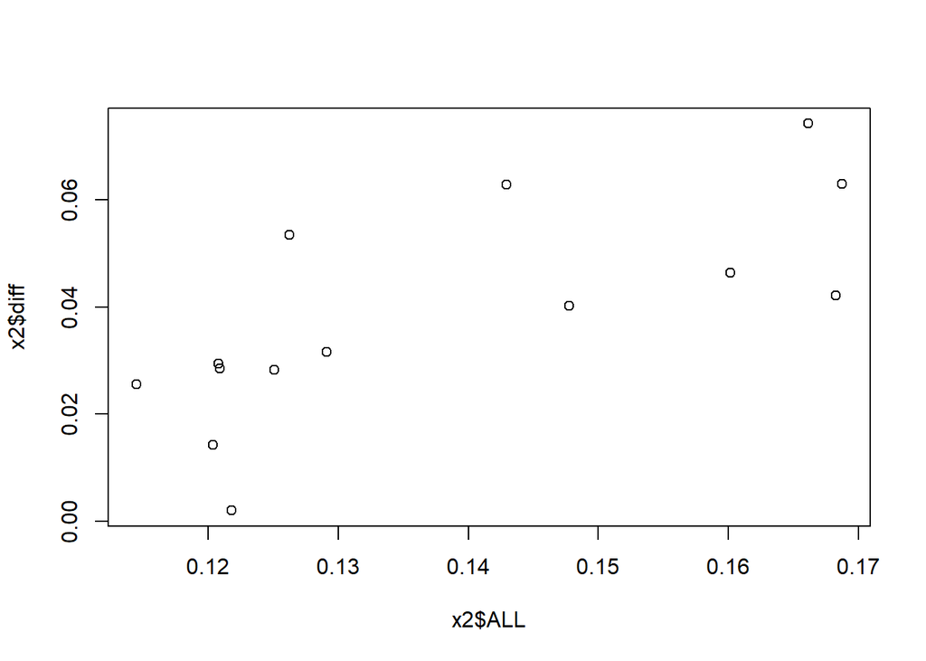

```r
plot(x2$ALL, x2$diff )
```

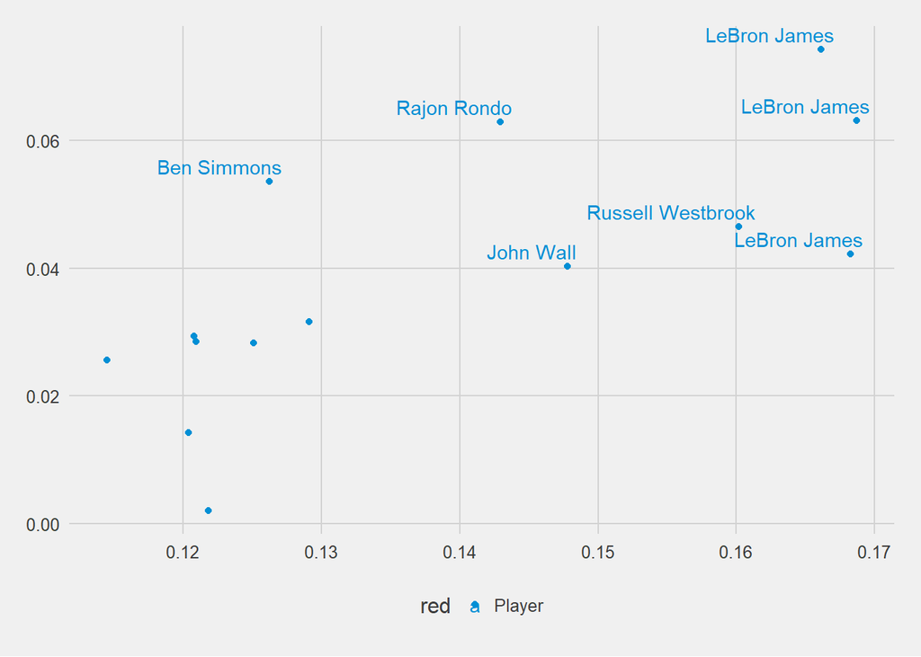

```r
ggplot(x2, aes(x= ALL, y= diff, colour="Player", label=Player))+
  geom_point() +
geom_text(aes(label=ifelse(ALL>0.14 | diff > 0.04,as.character(Player),'')),hjust=0.9,vjust=-0.5) +scale_color_fivethirtyeight("red") +
  theme_fivethirtyeight()
```

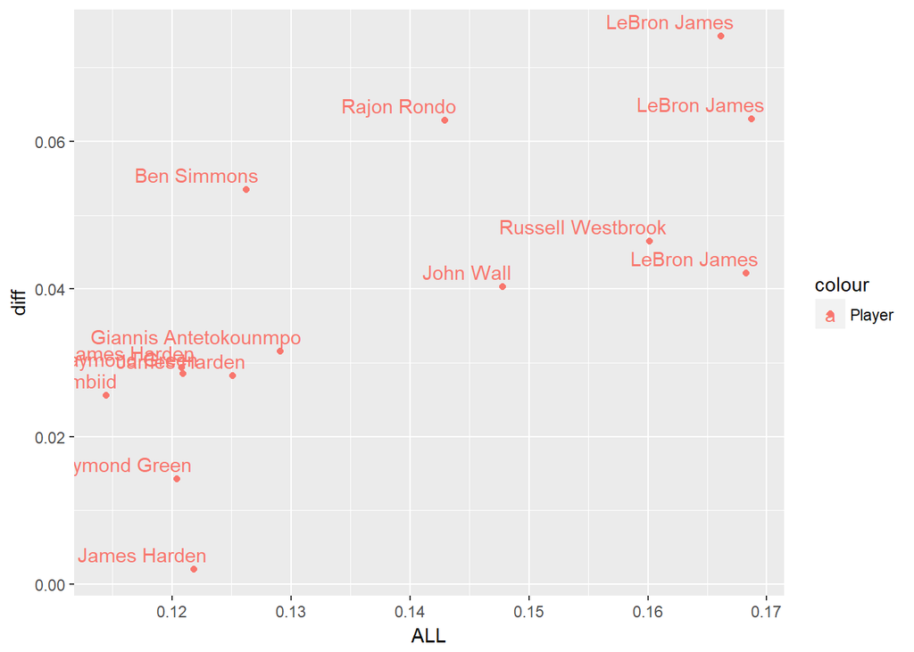

```r
ggplot(x2, aes(x= ALL, y= diff, colour="Player", label=Player))+
  geom_point() +
geom_text(aes(label=Player,hjust=0.9,vjust=-0.5))
```

Basic or advanced stats point to LeBron playing at a level we have never seen before - strengthing his case as THE greatest of all time. To avoid robbing Harden of the regular season MVP twice let’s give that to him. But win or lose LeBron James deserves to at least win the Finals MVP.

If you have payed the slightest of attention to this year’s playoffs, you know his numbers have been incredible - he leads the league in points, assits, minutes played and add to that he already has seven 40 point games (couple while facing elimination). But I want to compare his production from a slightly different angle. Let’s see how much impact James has had on the series relative to everyone else - combined.